# Programming

“1. Variable and Data Type”

“Wen-Bin Chuang”

“2024/07/25”

# Today’s Topics

- Simple Python Introduction
- Basic Knowledge
- Variable
- Data Type: Fundamental Types

# Introduction

Python is a modern programming language. It was created by Guido van Rossum, and released in 1991. It’s great as a first language because it is concise and easy to read. You can use it for web development, to handle big data, machine learning, data science, and software development. So, once you learn the fundamentals, you can grow into the role of your choice!

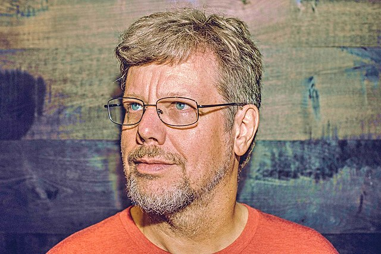

Python 2.0 vs. Python 3.0 Python version 1.0 was released in January 1994. The major new features included in this release were the functional programming tools lambda, map, filter and reduce, which Guido Van Rossum never liked. Six and a half years later in October 2000, *Python 2.0* was introduced.

Python flourished for another 8 years in the versions 2.x before the next major release as *Python 3.0* (also known as “Python 3000” and “Py3K”) was released. Python 3 is not backwards compatible with Python 2.x.

# Basic Knowledge

1. *print()* Function

```python
print("Orange", "Mango", "Apple")
print(f"Expected Portfolio Return: {portfolio_return}")
print(f"Annual Return: {calculate_annual_returns(monthly_returns):.2f}%")
```

2. *Comments* in Python

```python
# 2.1 Single-Line Comments
# This program displays an address.
print("National Chi-Nan University") #Displays School Name
print("Puli, Nantou")
```

```python
# 2.2 Multi-Line Comments
"""
This is a multi-line comment
that explains a block of code.
"""

print("Hello, world!")
```

3. Basic *Syntax* Rules

```python
# 3.1 Indentation: **4 space!!!!!!!**
if True:
    print("This is indented.")

from math import sqrt         # block 1
n = input("Maximum Number? ") # block 2
n = int(n)+1                  # block 3
for a in range(1,n):          # block 4
    for b in range(a,n):      # block 4.1 in 4
        c_square = a**2 + b**2
        c = int(sqrt(c_square))
        if ((c_square - c**2) == 0): # block 4. 1.1 in 4.1
            print(a, b, c)
```

```python
# 3.2 Statements:
# single-line statement
print("Hello, Python!")

# multi-line statement
my_list = [
  1, 2, 3,
  4, 5, 6
  ]
```

# Variables and Data Types

## Variables

- A variable is a name that represents a value in the computer’s memory. - we *assign =* value to it.

```python
a = 10
b = 15
c = a + b
print("Sum of numbers are", c)
```

## Naming Rule of Variable

To name variables in Python, you must follow these rules:

- A variable name can begin with a letter, dollar sign ($),or an underscore (_). It *must not* start with a number.
- A variable name should describe the kind of information that the variable stores. For example, firstName might be used to store a person’s first name. firstName rather than firstnarne
- A variable name should not be a *keyword* or reserved words
- A variable name cannot contain spaces.
- Uppercase and lowercase characters are distinct (score and Score).

```python
age = 25
name = "John"
email_address = "john@example.com"
total_sales = 500.50
first_name = "Mary"
```

```python
# Invalid variable names:
2nd_grade = 80    # cannot start with a number
first-name = "John"    # cannot use hyphens
total/sales = 500    # cannot use forward slash
email address = "john@example.com"    # cannot use spaces
if = 10    # cannot use Python keywords as variable names
```

# Data Type

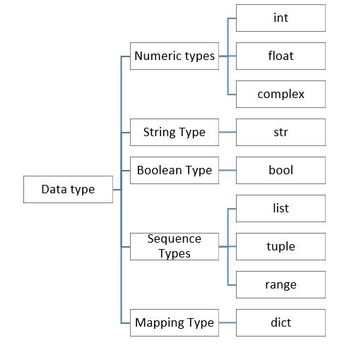

```python
x = 10        # int
y = 3.14      # float
z = x + y     # float
print(z)      # Output: 13.14
```

# **fundamental** types

**1.Strings**:

Each character in a string has an **index** that specifies its *position* in the string.

Strings can be enclosed in **single quotes (‘…’)** or **double quotes (“…”)**

[figure not shown]

## Slicing

```python
# slicing
s = "CBSE Python"
print(s[0:7]) # not 7
# CBSE Py

fruit = 'banana'
for letter in fruit:
    print (letter)
```

```python
first_name = "Harry"
last_name = "Porter"

full_name = first_name + " " + last_name # Concatenation
print(full_name) # Outputs: Harry Porter

# Interesting
"This is a string."
'This is also a string.'
```

```python
# repetition
print('go'*3) # 'gogogo'

# in operate
'a' in 'banana' # True

# length
fruit = 'banana'
len(fruit) # 6
```

```python
# try it
name = "Harry Porter"
print(name.title())

# try 2
print(name.upper())
print(name.lower())

str = 'python string methods'
str.capitalize()
# 'Python string methods'

str ='A2009'
str.replace('0','*')
# 'A2**9'
```

2. **Numbers:**

- Python supports *integers*, *floating point numbers*, and *complex numbers*.

```python
my_integer = 150
my_float = 5.2
sum = my_integer + my_float
print(sum) # Outputs: 155.2

# 4/2 # 2.0
2 * 3.0 # 6.0
3.0 ** 2 # 9.0
```

**3.Booleans**:

- Either **True** or **False**.

```python
x = 10
(x >= 5) & (x <= 11)
```

# **Dynamic Typing** and **Mutable**

```python
var = 12
print(var) # Outputs: 12

var = "Now I'm a string"
print(var) # Outputs: Now I'm a string
```

**Mutable** and **Immutable** Data Types - Mutable objects can **change their value** but keep their **id()**, which include *list*, *dict*, *set*. - Immutable objects cannot change their value and include **int**, *float*, *bool*, *string*, *tuple*.

# Operators Operators

Operators are categorized into several types: *arithmetic*, *comparison*, and *Relational, Logical assignment, and In* operators.

```python
# Arithmetic Operation
sum = 5 + 3
difference = 5 - 3
product = 5 * 3
quotient = 5 / 3
remainder = 5 % 3
quotientA = 5 // 3
power = 5 ** 3

10 / 3

10.0 / 3.0

9 // 3

10 // 3

11//3
```

```python
# Relational Operators - True or False
5 == 3
5 != 3
5 > 3
5 < 3
5 >= 3
5 <= 3
```

```python
# Assignment Operators
x = 5
x += 5 #  x = x + 5
x -= 5 #  x = x - 5
x *= 5 #  x = x * 5
x /= 5 #  x = x / 5
x %= 5 #  x = x % 5
x //= 5 #  x = x // 5
x **= 5 #  x = x ** 5
```

```python
# Logical Operator
x = 6
x < 5 and x < 10
# False
x < 5 or x < 10
# True
not(x < 5 and x < 10)
# True
```

```python
# in Operator
number = 33
number in (10,4,33,99)
# True
```

Converting Types

```python
age = input("Enter wer age: ") # input() returns a string
age = int(age) # Convert string to integer
print(f"we are {age} years old.")
```